# Project3 - Task1

Joshua Ludwig

2023-11-30

## Background

Our investigation revolves around determining the remaining explosive material in the soil of military training ranges. This concern stems from the potential health risks posed by explosive residues, known carcinogens that can adversely affect soldiers present on the training grounds. Our research involves collecting a representative soil sample from these ranges, focusing on the development, refinement, and validation of sampling methods.

Below, you’ll find the histogram detailing the distribution of Nitroglycerin measurements. Additionally, we’ve calculated the mean and variance of the dataset.

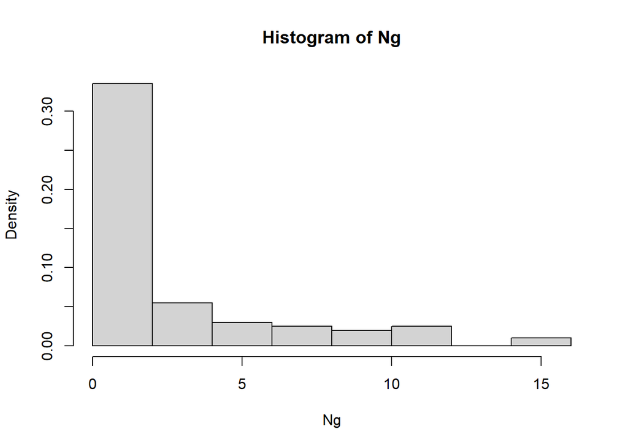

```r
library(data4soils)
Ng <- cfbp_fpjuliet$ng
hist(Ng, probability = TRUE)
```

```r
mean(Ng) # EV
```

```
## [1] 2.79164
```

```r
var(Ng)
```

```
## [1] 10.97915
```

### Parameter Exploration of $f_3$

In the course of exploring parameters for $f_3(x; \lambda) = \lambda e^{-\lambda x}$, I created two plots. The first utilized λ = 0.3, resulting in a specific plot. The second employed λ = 1, yielding a different representation. In summary, a higher λ value leads to a steeper line in the plot.

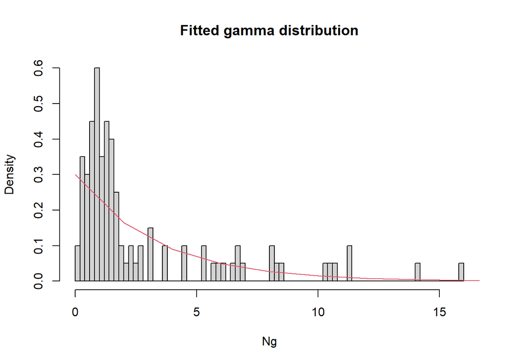

```r
# Define the f3 function
f3 <- function(x, l) {
  l * exp(-l * x)
}

# Generate x values for the plot
x <- seq(0, 20, 2)

# Plot for lambda = 0.3
hist(Ng, probability = TRUE, main = "Fitted gamma distribution", breaks = 100)
lines(x, f3(x, 0.3), col = 2)
```

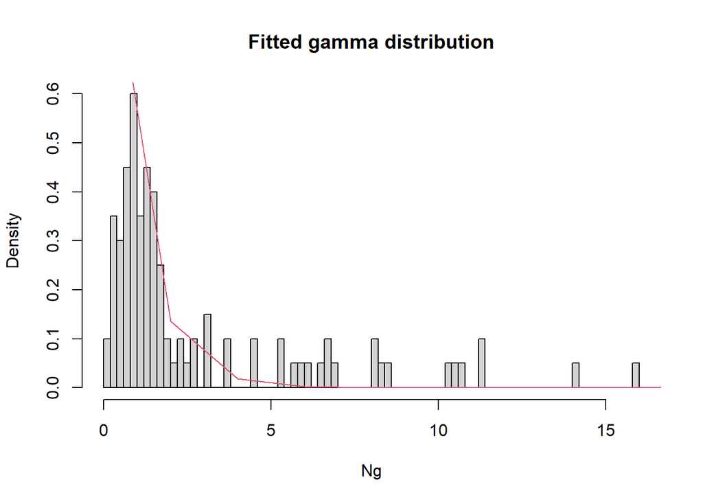

```r
# Plot for lambda = 1
hist(Ng, probability = TRUE, main = "Fitted gamma distribution", breaks = 100)
lines(x, f3(x, 1), col = 2)
```

### Visual Fitting of $f_2$ and $f_3$ to Nitroglycerin Measurements

For the probability density histogram of the 100 Nitroglycerin measurements, I visually fitted two functions:

#### $f_2(x; \alpha,\beta) = \frac{\beta^{\alpha}}{\Gamma(\alpha)}x^{\alpha-1}e^{-\beta x}$

The parameters α =0.7 and β=0.25 appeared to be fitting well.

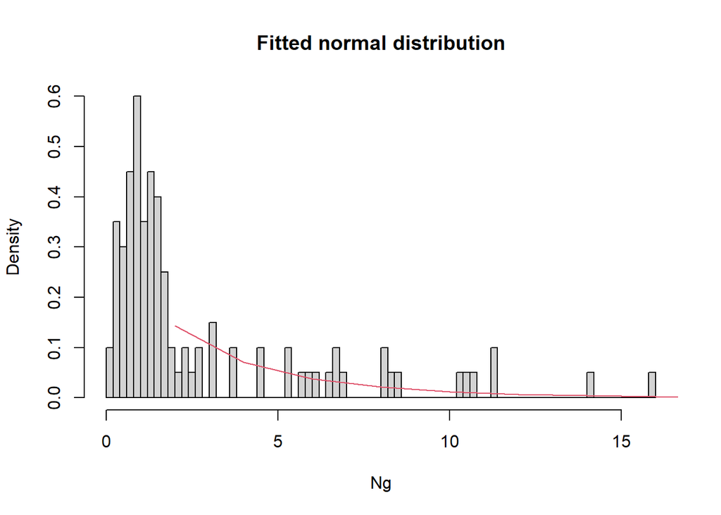

```r
# Define the f2 function
f2 <- function(x, a, b) {
  (b^a) / gamma(a) * x^(a - 1) * exp(-b * x)
}

# Plot for f2
hist(Ng, probability = TRUE, main = "Fitted normal distribution", breaks = 100)
lines(x, f2(x, 0.7, 0.25), col = 2)
```

#### $f_3(x; \lambda) = \lambda e^{-\lambda x}$

```r
set.seed(1228)
tmp2 <- rgamma(25000, shape = 0.7, rate = 0.25)
a <- length(which(tmp2 > 10))
probability_f2 <- a / 25000

# Print probabilities
cat("Probability for f2:", probability_f2, "\n")
```

```
## Probability for f2: 0.04468
```

### Simulation Results

```r
# Simulate data from f3 and count values above 10 mg/kg
tmp3 <- rexp(25000, rate = 0.75)
b <- length(which(tmp3 > 10))
probability_f3 <- b / 25000

cat("Probability for f3:", probability_f3)
```

```
## Probability for f3: 0.00072
```